# Processing data for water samples from 20250221 MiSeq run

Processing these data locally for now… 1. Used cutadapt to remove primers 2. unzipped files before going to dada2

```r
library(dada2)
library(dplyr)
```

```r
# file location
path <- "/Users/diana.baetscher/git-repos/NFS-Bogoslof/MiSeq_data/trimmed"
```

```r
fnFs <- sort(list.files(path, pattern = "_R1.fastq", full.names = TRUE))
fnRs <- sort(list.files(path, pattern = "_R2.fastq", full.names = TRUE))
# Extract sample names, assuming filenames have format: SAMPLENAME_XXX.fastq
sample.names <- sapply(strsplit(basename(fnFs), "_"), `[`, 1)
```

```r
plotQualityProfile(fnFs[1:2])
plotQualityProfile(fnRs[1:2])
```

[output not shown]

Read quality… not amazing universally. Probably good to trim somewhat liberally.

```r
# Place filtered files in filtered/ subdirectory
filtFs <- file.path(path, "filtered", paste0(sample.names, "_F_filt.fastq.gz"))
filtRs <- file.path(path, "filtered", paste0(sample.names, "_R_filt.fastq.gz"))
names(filtFs) <- sample.names
names(filtRs) <- sample.names
```

Initial filtering truncLen failed miserably. We changed it to be super-stringent to see how that affects downstream processing.

```r
out <- filterAndTrim(fnFs, filtFs, fnRs, filtRs, truncLen=c(100,100),
              maxN=0, maxEE=c(2,4), truncQ=2, rm.phix=TRUE,
              compress=TRUE, multithread=TRUE)
head(out)
```

Those filters worked decently for now - keeping a majority of the reads.

```r
# ensure there are no samples without reads
# as these don't work in the next steps
out %>%
  as.data.frame() %>%
  filter(reads.out <1)

# filter the matrix to retain samples with >0 reads
```

### Error rates

```r
# fwd error rates
errF <- learnErrors(filtFs, multithread=TRUE)

# reverse error rates
errR <- learnErrors(filtRs, multithread=TRUE)

# plot the erors
p1 <- plotErrors(errF, nominalQ=TRUE)
p2 <- plotErrors(errR, nominalQ=TRUE)
```

### Sample inference

```r
# forwards
dadaFs <- dada(filtFs, err=errF, multithread=TRUE)

# reverses
dadaRs <- dada(filtRs, err=errR, multithread=TRUE)
```

Merge paired end reads

```r
mergers <- mergePairs(dadaFs, filtFs, dadaRs, filtRs, verbose=TRUE)
# Inspect the merger data.frame from the first sample
head(mergers[[1]])
```

Make a sequence table

```r
seqtab <- makeSequenceTable(mergers)
dim(seqtab)
```

```r
# Inspect distribution of sequence lengths
table(nchar(getSequences(seqtab)))
```

Let’s remove the singletons and off-target sequences

```r
#seqtab2 <- seqtab[,nchar(colnames(seqtab)) %in% 168:172]
seqtab2 <- seqtab[,nchar(colnames(seqtab)) %in% 162:182]
```

Remove chimeras

```r
seqtab.nochim <- removeBimeraDenovo(seqtab2, method="consensus", multithread=TRUE, verbose=TRUE)
dim(seqtab.nochim)
```

Calculate frequency of chimeras

```r
sum(seqtab.nochim)/sum(seqtab2)
```

Track reads through the pipeline

```r
getN <- function(x) sum(getUniques(x))
track <- cbind(out, sapply(dadaFs, getN), sapply(dadaRs, getN), sapply(mergers, getN), rowSums(seqtab.nochim))

colnames(track) <- c("input", "filtered", "denoisedF", "denoisedR", "merged", "nonchim")
rownames(track) <- sample.names
head(track)
```

Again, a lot of data loss at the merge step.

## Export files for taxonomy and samples/ASVs

```r
 #make fasta file with ASVs
    asv_seqs=colnames(seqtab.nochim)
    for(i in 1:length(asv_seqs))
    {
        write.table(paste(">ASV",i, sep=""),file="csv_outputs/NFS_MiFish_ASV_seqtab_nochim_20250221_wider.csv", append=TRUE, col.names = F, row.names = F, quote=F)
        write.table(paste(asv_seqs[i], sep=""),file="csv_outputs/NFS_MiFish_ASV_seqtab_nochim_20250221_wider.csv", append=TRUE, col.names = F, row.names = F, quote=F)
    }
```

That’s the input for the FASTA blastn search.

Goal: change ASV headers to numbered ASVs that correspond to those output in the FASTA file.

```r
# Make map between brief names and full sequences
briefToSeq <- colnames(seqtab.nochim)
names(briefToSeq) <- paste0("ASV", seq(ncol(seqtab.nochim))) # Seq1, Seq2, ...
# Make new sequence table with brief names
st.brief <- seqtab.nochim
colnames(st.brief) <- names(briefToSeq)

# export the pool seq table with brief names:
write.csv(st.brief, file="csv_outputs/NFS_MiFish_ASVtable_20250221_wider.csv")
```

Now move on to the blastn taxonomy search.

## Taxonomy outputs

I ran blastn on Sedna and then taxonkit locally.

```r
library(tidyverse)
taxonomy <- read_tsv("../blast_outputs/blastn_taxlineage_NFS_wider.txt", col_names = F)
head(taxonomy)
```

| X1 | X2 | X3 | X4 | X5 | X6 | X7 | X8 | X9 | X10 | X11 | X12 | X13 | X14 | X15 | X16 | X17 |
| --- | --- | --- | --- | --- | --- | --- | --- | --- | --- | --- | --- | --- | --- | --- | --- | --- |
| ASV1 | gi\|985565645\|dbj\|LC036761.1\| | 100 | 169 | 0 | 0 | 1 | 169 | 1 | 169 | 1.26e-80 | 313 | N/A | 192379 | 192379 | cellular organisms;Eukaryota;Opisthokonta;Metazoa;Eumetazoa;Bilateria;Deuterostomia;Chordata;Craniata;Vertebrata;Gnathostomata;Teleostomi;Euteleostomi;Actinopterygii;Actinopteri;Neopterygii;Teleostei;… | ;Chordata;Actinopteri;Perciformes;Hexagrammidae;Pleurogrammus;Pleurogrammus monopterygius |
| ASV1 | gi\|2491777358\|gb\|OQ846553.1\| | 100 | 169 | 0 | 0 | 1 | 169 | 1 | 169 | 1.26e-80 | 313 | N/A | 192379 | 192379 | cellular organisms;Eukaryota;Opisthokonta;Metazoa;Eumetazoa;Bilateria;Deuterostomia;Chordata;Craniata;Vertebrata;Gnathostomata;Teleostomi;Euteleostomi;Actinopterygii;Actinopteri;Neopterygii;Teleostei;… | ;Chordata;Actinopteri;Perciformes;Hexagrammidae;Pleurogrammus;Pleurogrammus monopterygius |
| ASV1 | gi\|584593839\|ref\|NC_023475.1\| | 100 | 169 | 0 | 0 | 1 | 169 | 314 | 482 | 1.26e-80 | 313 | N/A | 192379 | 192379 | cellular organisms;Eukaryota;Opisthokonta;Metazoa;Eumetazoa;Bilateria;Deuterostomia;Chordata;Craniata;Vertebrata;Gnathostomata;Teleostomi;Euteleostomi;Actinopterygii;Actinopteri;Neopterygii;Teleostei;… | ;Chordata;Actinopteri;Perciformes;Hexagrammidae;Pleurogrammus;Pleurogrammus monopterygius |
| ASV1 | gi\|31076436\|dbj\|AB109300.1\| | 100 | 169 | 0 | 0 | 1 | 169 | 1232 | 1400 | 1.26e-80 | 313 | N/A | 192379 | 192379 | cellular organisms;Eukaryota;Opisthokonta;Metazoa;Eumetazoa;Bilateria;Deuterostomia;Chordata;Craniata;Vertebrata;Gnathostomata;Teleostomi;Euteleostomi;Actinopterygii;Actinopteri;Neopterygii;Teleostei;… | ;Chordata;Actinopteri;Perciformes;Hexagrammidae;Pleurogrammus;Pleurogrammus monopterygius |
| ASV2 | gi\|1799624477\|gb\|MN122852.1\| | 100 | 169 | 0 | 0 | 1 | 169 | 321 | 489 | 1.26e-80 | 313 | N/A | 8049 | 8049 | cellular organisms;Eukaryota;Opisthokonta;Metazoa;Eumetazoa;Bilateria;Deuterostomia;Chordata;Craniata;Vertebrata;Gnathostomata;Teleostomi;Euteleostomi;Actinopterygii;Actinopteri;Neopterygii;Teleostei;… | ;Chordata;Actinopteri;Gadiformes;Gadidae;Gadus;Gadus morhua |
| ASV2 | gi\|1783586359\|gb\|MH035595.1\| | 100 | 169 | 0 | 0 | 1 | 169 | 321 | 489 | 1.26e-80 | 313 | N/A | 1042646 | 1042646 | cellular organisms;Eukaryota;Opisthokonta;Metazoa;Eumetazoa;Bilateria;Deuterostomia;Chordata;Craniata;Vertebrata;Gnathostomata;Teleostomi;Euteleostomi;Actinopterygii;Actinopteri;Neopterygii;Teleostei;… | ;Chordata;Actinopteri;Gadiformes;Gadidae;Gadus;Gadus chalcogrammus |

```r
tax_df <- taxonomy %>%
  filter(!str_detect(X16, "environmental")) %>% # get rid of any environmental samples
  select(X1, X3, X17) %>% #remove unnecessary columns
  group_by(X1, X17) %>% # group by the sequence key and the full taxonomy to reduce duplicate entries
  unique() %>% # doing that reduced the number of entries from 146k to 17k
  filter(!is.na(X17)) %>%
  separate(X17, into=c("kingdom", "phylum", "class", "order", "family", "genus", "species"), sep = ";") %>%
  select(-kingdom) %>%
  dplyr::rename(ASV = X1, perc_id = X3) %>%
  filter(!family %in% c("Hominidae", "Bovidae", "Canidae", "Suidae")) # remove these up front.
```

## Taxonomic filtering

Using a 1% identity filter!

For species-level matches: 1. Any ASV that matches only a single species.

```r
tax_asv_top_perc <- tax_df %>%
  mutate(species = ifelse(str_detect(species, " sp\\."), NA, species)) %>%
  # remove other stuff that isn't on-target or out of range
  filter(!species %in% c("Oncorhynchus kawamurae", "Ammodytes japonicus", "Sebastes baramenuke", "Sebastes cheni", "Sebastes inermis", "uncultured bacterium", "Hexagrammos otakii", "Clupea harengus")) %>% # remove species outside of their range
  filter(family != "Phasianidae") %>%
  group_by(ASV, species) %>%
  slice_max(perc_id, n = 1)
  # take the highest perc_id for a single species (taxonomy) entry per ASV
# this remove entries for a given species/ASV at different percent ids

single_spp_taxa <-tax_asv_top_perc %>%
  tally() %>%
  ungroup() %>%
  group_by(ASV) %>%
  tally() %>%
  filter(n == 1) %>%
  left_join(., tax_asv_top_perc, by = "ASV") %>%
  select(-n) %>%
  mutate(taxon = species, taxonomic_level = "species")
```

61 ASVs have a single species taxonomic match.

```r
# with the multi-species ASVs, rank the species in the top 1% based on identity
id_ranked_df <- tax_asv_top_perc %>%
  anti_join(., single_spp_taxa, by = "ASV") %>%
  group_by(ASV) %>%
  mutate(id_rank = rank(desc(perc_id), ties.method = "min")) %>% # rank the taxonomic hits per sequence by % id
  mutate(top_perc = max(perc_id)) %>% # designate the highest % id for the best taxonomic hit in each sequence (in some, but not all cases, this is 100%)
  arrange(ASV) %>%
  mutate(perc_diff = top_perc-perc_id) %>%
  filter(!perc_diff > 1) # 1% difference #### EDIT THIS FOR THE % DIFFERENCE ####
```

```r
# now determine which ASVs are single-species based on the top 1%
species_level_asv <- id_ranked_df %>%
  group_by(ASV, species) %>%
  tally() %>%
  group_by(ASV) %>%
  tally() %>%
  filter(n == 1) %>%
  left_join(., id_ranked_df, by = "ASV") %>%
  select(-n) %>%
  filter(perc_id == top_perc) %>%
  filter(!is.na(species)) %>% # remove the sequences without species-level ids
  mutate(taxon = species, taxonomic_level = "species")
```

an additional 23 ASVs that have a single taxonomic identity within the top 1% of blast matches.

```r
# genus-level
  single_genus <- id_ranked_df %>%
    anti_join(., species_level_asv, by = "ASV") %>%
    group_by(ASV, genus) %>%
    tally() %>%
    ungroup() %>%
    group_by(ASV) %>%
    tally(name = "n_genera") %>%
    filter(n_genera == 1) %>% # sequences that match only a single genus
    select(-n_genera) %>%
    left_join(., id_ranked_df) %>%
    filter(!is.na(genus)) %>% # get rid of sequences that are NA at the genus level
    mutate(taxonomic_level = "genus") %>%
    mutate(taxon = genus)
# single family
single_family <- id_ranked_df %>%
    anti_join(., species_level_asv, by = "ASV") %>%
    anti_join(., single_genus, by = "ASV") %>%
    group_by(ASV, family) %>%
    tally() %>%
    ungroup() %>%
    group_by(ASV) %>%
    tally(name = "n_families") %>%
    filter(n_families == 1) %>% # sequences that match only a single genus
    select(-n_families) %>%
    left_join(., id_ranked_df) %>%
    filter(!is.na(family)) %>% # get rid of sequences that are NA at the genus level
    mutate(taxonomic_level = "family") %>%
    mutate(taxon = family)
single_family
```

| ASV | perc_id | phylum | class | order | family | genus | species | id_rank | top_perc | perc_diff | taxonomic_level | taxon |
| --- | --- | --- | --- | --- | --- | --- | --- | --- | --- | --- | --- | --- |
| ASV106 | 99.419 | Chordata | Actinopteri | Clupeiformes | Clupeidae | Clupea | Clupea pallasii | 1 | 99.419 | 0.000 | family | Clupeidae |
| ASV106 | 98.837 | Chordata | Actinopteri | Clupeiformes | Clupeidae | Sprattus | Sprattus sprattus | 2 | 99.419 | 0.582 | family | Clupeidae |
| ASV129 | 98.824 | Chordata | Actinopteri | Gadiformes | Gadidae | Arctogadus | Arctogadus glacialis | 4 | 99.412 | 0.588 | family | Gadidae |
| ASV129 | 99.412 | Chordata | Actinopteri | Gadiformes | Gadidae | Gadus | Gadus chalcogrammus | 1 | 99.412 | 0.000 | family | Gadidae |
| ASV129 | 99.412 | Chordata | Actinopteri | Gadiformes | Gadidae | Gadus | Gadus finnmarchicus | 1 | 99.412 | 0.000 | family | Gadidae |
| ASV129 | 98.824 | Chordata | Actinopteri | Gadiformes | Gadidae | Gadus | Gadus macrocephalus | 4 | 99.412 | 0.588 | family | Gadidae |
| ASV129 | 99.412 | Chordata | Actinopteri | Gadiformes | Gadidae | Gadus | Gadus morhua | 1 | 99.412 | 0.000 | family | Gadidae |
| ASV132 | 98.824 | Chordata | Actinopteri | Gadiformes | Gadidae | Arctogadus | Arctogadus glacialis | 5 | 99.412 | 0.588 | family | Gadidae |
| ASV132 | 99.412 | Chordata | Actinopteri | Gadiformes | Gadidae | Gadus | Gadus chalcogrammus | 1 | 99.412 | 0.000 | family | Gadidae |
| ASV132 | 99.412 | Chordata | Actinopteri | Gadiformes | Gadidae | Gadus | Gadus finnmarchicus | 1 | 99.412 | 0.000 | family | Gadidae |

[output cut: 386 more lines]

```r
# single order
  single_order <- id_ranked_df %>%
    anti_join(., species_level_asv, by = "ASV") %>%
    anti_join(., single_genus, by = "ASV") %>%
    anti_join(., single_family, by = "ASV") %>%
    group_by(ASV, order) %>%
    tally() %>%
    ungroup() %>%
    group_by(ASV) %>%
    tally() %>%
    filter(n == 1) %>% # sequences that match only a single order
    select(-n) %>%
    left_join(., id_ranked_df) %>%
    filter(!is.na(order)) %>%
    mutate(taxonomic_level = "order") %>%
    mutate(taxon = order)
  # single class
  single_class <- id_ranked_df %>%
    anti_join(., species_level_asv, by = "ASV") %>%
    anti_join(., single_genus, by = "ASV") %>%
    anti_join(., single_family, by = "ASV") %>%
    anti_join(single_order, by = "ASV") %>%
    group_by(ASV, class) %>%
    tally() %>%
    ungroup() %>%
    group_by(ASV) %>%
    tally() %>%
    filter(n == 1) %>% # sequences that match only a single class
    select(-n) %>%
    left_join(., id_ranked_df) %>%
    filter(!is.na(class)) %>%
    mutate(taxonomic_level = "class") %>%
    mutate(taxon = class)
  # single phylum
  single_phylum <- id_ranked_df %>%
   anti_join(., species_level_asv, by = "ASV") %>%
    anti_join(., single_genus, by = "ASV") %>%
    anti_join(., single_family, by = "ASV") %>%
    anti_join(single_order, by = "ASV") %>%
    anti_join(single_class, by = "ASV") %>%
    group_by(ASV, phylum) %>%
    tally() %>%
    ungroup() %>%
    group_by(ASV) %>%
    tally() %>%
    filter(n == 1) %>% # sequences that match only a single phylum
    select(-n) %>%
    left_join(., id_ranked_df) %>%
    filter(!is.na(phylum)) %>%
    mutate(taxonomic_level = "phylum") %>%
    mutate(taxon = phylum)
```

```r
# this dataframe still has multiple taxonomic entries per sequence
# only by selecting the taxon column can we fully collapse the df
taxonomy_combined <- bind_rows(single_spp_taxa, species_level_asv, single_genus, single_family, single_order, single_class, single_phylum) %>%
   mutate(top_perc = ifelse(is.na(top_perc), perc_id, top_perc)) %>%
    mutate(id_rank = ifelse(is.na(id_rank), 1, id_rank)) %>%
     mutate(perc_diff = ifelse(is.na(perc_diff), 0, perc_diff))


# how many species-level assignments are <98% identity?
# let's switch those to genus-level IDs
taxonomy_rank_mult_entries <- taxonomy_combined %>%
  select(-perc_diff) %>%
  #filter(id_rank == 1) %>%  # this will make this df smaller, but the assignment is based on the taxon/taxonomic_level, which includes multiple ranks
  mutate(taxon = ifelse(taxonomic_level == "species" & perc_id < 98, genus, taxon)) %>%
  mutate(taxonomic_level = ifelse(taxonomic_level == "species" & perc_id < 98, "genus", taxonomic_level))
```

```r
taxonomy_rank_mult_entries %>%
  select(taxon, taxonomic_level) %>%
  unique()
```

| taxon | taxonomic_level |
| --- | --- |
| Pleurogrammus monopterygius | species |
| Acipenser fulvescens | species |
| Oncorhynchus tshawytscha | species |
| Allocareproctus jordani | species |
| Stenobrachius leucopsarus | species |
| Balaenoptera physalus | species |
| Eumetopias jubatus | species |
| Phocoenoides dalli | species |
| Orcinus orca | species |
| Leuroglossus schmidti | species |

[output cut: 26 more lines]

```r
NA
```

330 unique ASV/taxa 36 unique taxa (excluding ASVs)

## what non-fish are here?

| species | genus | family | order |
| --- | --- | --- | --- |
| Balaenoptera physalus | Balaenoptera | Balaenopteridae | Artiodactyla |
| Eumetopias jubatus | Eumetopias | Otariidae | Carnivora |
| Phocoenoides dalli | Phocoenoides | Phocoenidae | Artiodactyla |
| Orcinus orca | Orcinus | Delphinidae | Artiodactyla |
| Callorhinus ursinus | Callorhinus | Otariidae | Carnivora |
| Ardenna tenuirostris | Ardenna | Procellariidae | Procellariiformes |

all of those make sense.

```r
multi_hit_asv_df <- taxonomy_rank_mult_entries %>%
  filter(!is.na(phylum)) %>%
  group_by(ASV) %>%
  add_tally(name = "n_taxonomic_hits") %>%
 # --- STEP 1: extract epithet
  mutate(epithet = word(species, 2)) %>%

  # --- STEP 2: compute genus- and family-level combined names
  group_by(ASV) %>%
  mutate(
    # GENUS-LEVEL: "Genus epithet1/epithet2/epithet3"
    combined_genus_epithet = if_else(
      taxonomic_level == "genus" & n_taxonomic_hits < 4,
      paste0(
        first(genus), " ",
        paste(unique(epithet), collapse = "/")
      ),
      taxon
    ),

    # FAMILY-LEVEL: "Genus1/Genus2"
    combined_family_species = if_else(
      taxonomic_level == "family" & n_taxonomic_hits < 4,
      paste(unique(genus), collapse = "/"),
      NA_character_
    )
  ) %>%
  ungroup() %>%


  # --- STEP 3: choose final hit label
  mutate(
    hit = case_when(
      n_taxonomic_hits == 1 ~ taxon,
      taxonomic_level == "genus"  ~ combined_genus_epithet,
      taxonomic_level == "family" ~ combined_family_species,
      TRUE ~ NA_character_
    )
  )
```

```r
samples <- read_csv("csv_outputs/NFS_MiFish_ASVtable_20250221_wider.csv") %>%
  rename(sample = `...1`)
multi_tax_sample_df <- samples %>%
  pivot_longer(2:length(samples), names_to = "ASV", values_to = "reads") %>%
  filter(reads > 0) %>%
  left_join(., multi_hit_asv_df) %>%
  filter(!is.na(phylum)) %>%
  mutate(hit = ifelse(is.na(hit), taxon, hit)) %>%
  select(sample, reads, hit) %>%
  unique()
multi_tax_sample_df
```

| sample | reads | hit |
| --- | --- | --- |
| e02598-1 | 47 | Pleurogrammus monopterygius |
| e02598-1 | 102 | Gadus |
| e02598-1 | 64 | Oncorhynchus keta/nerka |
| e02598-1 | 14 | Bathymaster leurolepis/signatus |
| e02598-1 | 2 | Clupea/Sprattus |
| e02598-2 | 60 | Pleurogrammus monopterygius |
| e02598-2 | 43 | Leuroglossus schmidti/stilbius |
| e02598-2 | 54607 | Oncorhynchus keta/nerka |
| e02598-2 | 16 | Stenobrachius leucopsarus/nannochir |
| e02598-2 | 44 | Gadidae |

[output cut: 990 more lines]

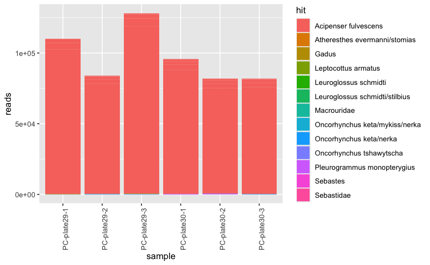

```r
multi_tax_sample_df %>%
  filter(str_detect(sample, "PC")) %>%
   ggplot(aes(x = sample, y = reads, fill = hit)) +
  geom_bar(stat = "identity", position = "stack") +
  theme(
    axis.text.x = element_text(angle = 90)
  )
```

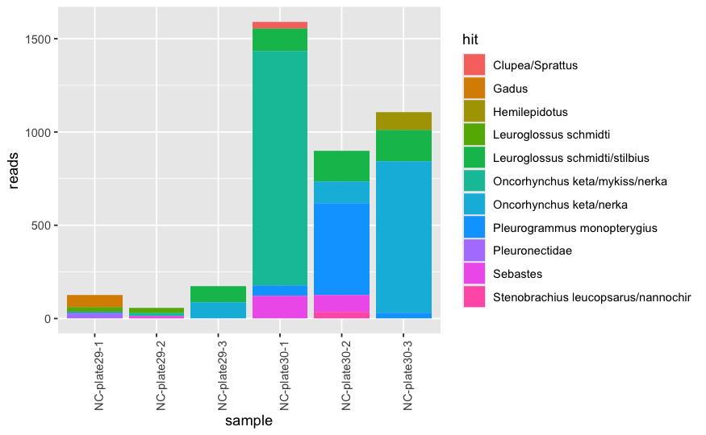

```r
multi_tax_sample_df %>%
  filter(str_detect(sample, "NC")) %>%
   ggplot(aes(x = sample, y = reads, fill = hit)) +
  geom_bar(stat = "identity", position = "stack") +
  theme(
    axis.text.x = element_text(angle = 90)
  )
```

[output not shown]

[output cut: 83 more lines]

In the samples that we’re planning on retaining, how many Sturgeon reads?

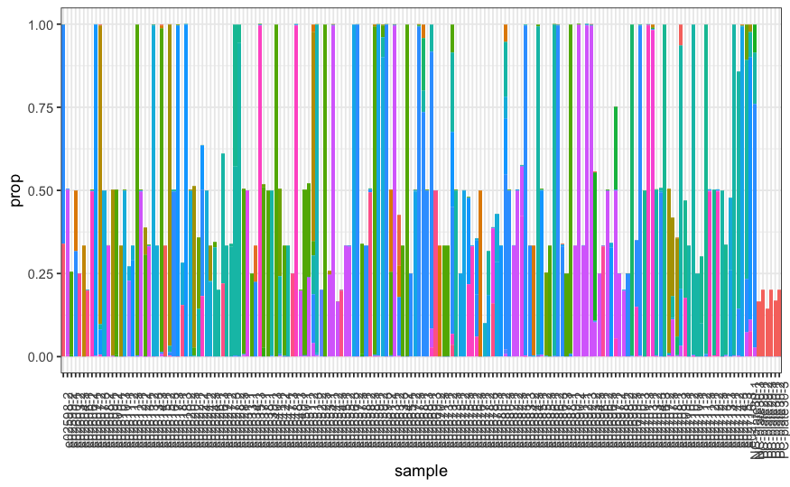

```r
# filtering steps by read depth, etc.
multi_tax_sample_df %>%
  group_by(sample, hit) %>%
  mutate(spp_reads = sum(reads)) %>%
  group_by(sample) %>%
  mutate(total_reads = sum(spp_reads)) %>%
  filter(total_reads > 1000) %>%
  mutate(prop = spp_reads/total_reads) %>%
    select(sample, hit, spp_reads, total_reads, prop) %>%
    unique() %>%
  separate(sample, into = c("id", "rep"), remove = F) %>%
  ggplot(aes(x = sample, y = prop, fill = hit)) +
  geom_bar(stat = "identity", position = "stack") +
  theme_bw() +
  theme(
    legend.position = "none",
    axis.text.x = element_text(angle = 90)
  )
```

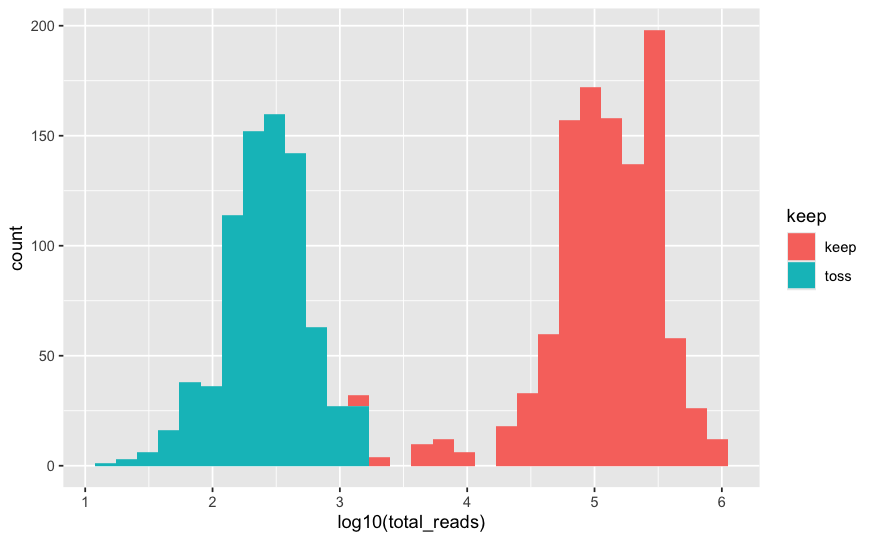

```r
multi_tax_sample_df %>%
  group_by(sample, hit) %>%
  mutate(spp_reads = sum(reads)) %>%
  group_by(sample) %>%
  mutate(total_reads = sum(spp_reads)) %>%
  select(sample, total_reads) %>%
  #filter(total_reads < 20000) %>%
  mutate(keep = ifelse(total_reads > 1500, "keep", "toss")) %>%
  ggplot(aes(x = log10(total_reads), fill = keep)) +
  geom_histogram()
```

```r
multi_tax_sample_df %>%
  group_by(sample, hit) %>%
  mutate(spp_reads = sum(reads)) %>%
  group_by(sample) %>%
  mutate(total_reads = sum(spp_reads)) %>%
  ungroup() %>%
  select(sample, total_reads) %>%
  unique() %>%
  summarise(median(total_reads))
```

| median(total_reads) |
| --- |
| 673 |

```r
NA
```

The number of reads per replicate is wild. I think I probably end up ditching the low-read depth replicates rather than summing them together.

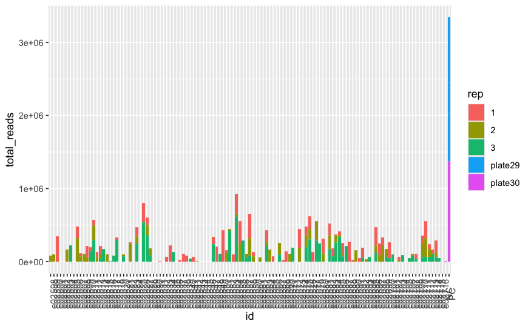

```r
multi_tax_sample_df %>%
  group_by(sample, hit) %>%
  mutate(spp_reads = sum(reads)) %>%
  group_by(sample) %>%
  mutate(total_reads = sum(spp_reads)) %>%
  ungroup() %>%
  select(sample, total_reads) %>%
  unique() %>%
  separate(sample, into = c("id", "rep")) %>%
  ggplot(aes(x = id, y = total_reads, fill = rep)) +
  geom_bar(stat = "identity", position = "stack") +
  theme(
    axis.text.x = element_text(angle = 90)
  )
```

Given that amount of variation, let’s just see what we have using reasonable filters:

| sample | total_reads |
| --- | --- |
| e02598-2 | 82910 |
| e02599-2 | 101073 |
| e02600-1 | 342827 |
| e02603-2 | 159474 |
| e02604-3 | 225044 |
| e02606-1 | 150058 |
| e02606-2 | 324896 |
| e02607-1 | 41037 |
| e02607-2 | 68128 |
| e02607-3 | 4333 |

[output cut: 158 more lines]

168 sample/replicates with >1000 reads

```r
keeper_tax_df <- multi_tax_sample_df %>%
  inner_join(., samples_to_keep) %>%
  group_by(sample, hit) %>%
  mutate(spp_reads = sum(reads)) %>%
  select(sample, hit, spp_reads) %>% # need this here, otherwise the proportions don't sum to 1
  unique() %>%
  group_by(sample) %>%
  mutate(total_reads = sum(spp_reads)) %>%
  filter(total_reads > 1000) %>%
  select(sample, hit, spp_reads, total_reads) %>%
  unique() %>%
  mutate(prop = spp_reads/total_reads)
```

| sample | hit | spp_reads | total_reads | prop |
| --- | --- | --- | --- | --- |
| e02606-2 | Acipenser fulvescens | 6 | 65296 | 9.188924e-05 |
| e02607-3 | Acipenser fulvescens | 11 | 4333 | 2.538657e-03 |
| e02612-2 | Acipenser fulvescens | 4 | 32252 | 1.240233e-04 |
| e02615-1 | Acipenser fulvescens | 17 | 4355 | 3.903559e-03 |
| e02631-1 | Acipenser fulvescens | 3 | 3602 | 8.328706e-04 |
| e02654-1 | Acipenser fulvescens | 22 | 68712 | 3.201770e-04 |
| e02654-2 | Acipenser fulvescens | 38 | 48062 | 7.906454e-04 |
| e02654-3 | Acipenser fulvescens | 73 | 102297 | 7.136084e-04 |
| e02656-3 | Acipenser fulvescens | 113 | 96326 | 1.173100e-03 |
| e02678-2 | Acipenser fulvescens | 18 | 25996 | 6.924142e-04 |

[output cut: 16 more lines]

| sample | hit | spp_reads | total_reads | prop |
| --- | --- | --- | --- | --- |
| e02598-2 | Leuroglossus schmidti/stilbius | 43 | 82910 | 5.186347e-04 |
| e02598-2 | Stenobrachius leucopsarus/nannochir | 16 | 82910 | 1.929803e-04 |
| e02598-2 | Gadidae | 44 | 82910 | 5.306959e-04 |
| e02599-2 | Gadus | 12 | 50942 | 2.355620e-04 |
| e02603-2 | Pleurogrammus monopterygius | 24 | 79752 | 3.009329e-04 |
| e02603-2 | Gadus | 6 | 79752 | 7.523322e-05 |
| e02606-1 | Gadus | 48 | 50106 | 9.579691e-04 |
| e02606-1 | Oncorhynchus keta/nerka | 41 | 50106 | 8.182653e-04 |
| e02606-1 | Stenobrachius leucopsarus/nannochir | 27 | 50106 | 5.388576e-04 |
| e02606-1 | Sebastes | 14 | 50106 | 2.794077e-04 |

[output cut: 283 more lines]

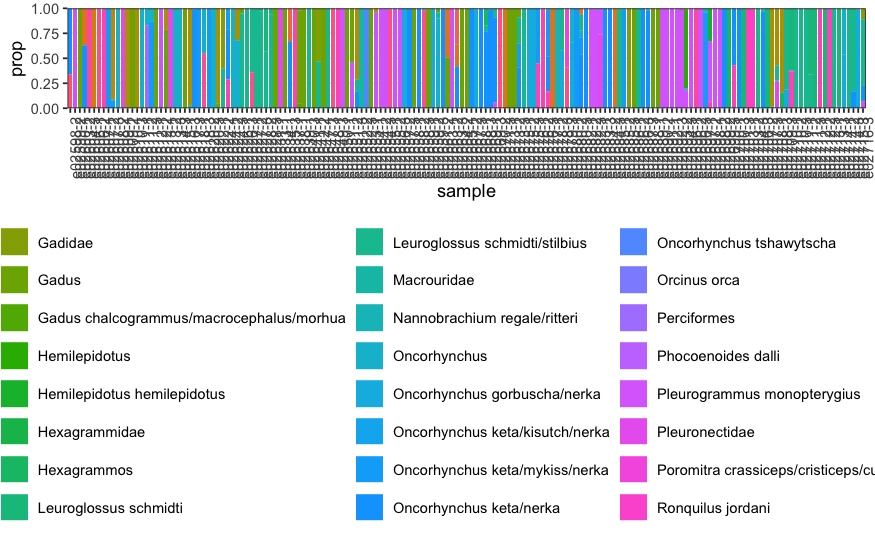

```r
keeper_df %>%
  ggplot(aes(x = sample, y = prop, fill = hit)) +
  geom_bar(stat = "identity", position = "stack") +
  theme_bw() +
  theme(
    legend.position = "bottom",
    axis.text.x = element_text(angle = 90)
  ) +
  scale_y_continuous(expand = c(0,0))

ggsave("pdf_outputs/eDNA_quicklook_20260120.png", height = 10, width = 10)
```

Next steps: 1. Sum across replicates for a given sample 2. Add in metadata

| extraction_ID | lat | lon | Year | Month | Day | Transect | StationKM | DepthM | SampleNumber | SampleType | Sampler1 | Sampler2 | Notes | source | collection_year | collection_month | collection_day | location1 | location2 | location3 | longitude | latitude | sample_type | depth | time_of_day | project | collected_by | extraction_by | extraction_date | … |
| --- | --- | --- | --- | --- | --- | --- | --- | --- | --- | --- | --- | --- | --- | --- | --- | --- | --- | --- | --- | --- | --- | --- | --- | --- | --- | --- | --- | --- | --- | --- |
| e02598 | 53.39740 | -169.2485 | 2023 | 8 | 7 | west | 100 | 15 | 1 | eDNA | D. Baetscher | T. Zeppelin | Niskin top didn't close | water | 2023 | 8 | 7 | Bogoslof | west | 100 | NA | NA | sample | 15 | NA | Bogo fur seal eDNA | D. Baetscher | JLM | 10/10/2023 | … |
| e02599 | 53.39740 | -169.2485 | 2023 | 8 | 7 | west | 100 | 15 | 2 | eDNA | D. Baetscher | T. Zeppelin | Niskin top didn't close | water | 2023 | 8 | 7 | Bogoslof | west | 100 | NA | NA | sample | 15 | NA | Bogo fur seal eDNA | D. Baetscher | JLM | 10/10/2023 | … |
| e02600 | 53.39740 | -169.2485 | 2023 | 8 | 7 | west | 100 | 15 | 3 | eDNA | D. Baetscher | T. Zeppelin | Niskin top didn't close | water | 2023 | 8 | 7 | Bogoslof | west | 100 | NA | NA | sample | 15 | NA | Bogo fur seal eDNA | D. Baetscher | JLM | 10/10/2023 | … |
| e02601 | NA | NA | 2023 | 8 | 7 | west | NA | 15 | 4 | FieldBlank | D. Baetscher | T. Zeppelin | NA | water | 2023 | 8 | 7 | Bogoslof | west | NA | NA | NA | field_blank | 15 | NA | Bogo fur seal eDNA | D. Baetscher | JLM | 10/10/2023 | … |
| e02602 | 53.45133 | -169.1278 | 2023 | 8 | 7 | west | 90 | 15 | 5 | eDNA | D. Baetscher | T. Zeppelin | NA | water | 2023 | 8 | 7 | Bogoslof | west | 90 | NA | NA | sample | 15 | NA | Bogo fur seal eDNA | D. Baetscher | JLM | 10/11/2023 | … |
| e02603 | 53.45133 | -169.1278 | 2023 | 8 | 7 | west | 90 | 15 | 6 | eDNA | D. Baetscher | T. Zeppelin | NA | water | 2023 | 8 | 7 | Bogoslof | west | 90 | NA | NA | sample | 15 | NA | Bogo fur seal eDNA | D. Baetscher | JLM | 10/11/2023 | … |
| e02604 | 53.45133 | -169.1278 | 2023 | 8 | 7 | west | 90 | 15 | 7 | eDNA | D. Baetscher | T. Zeppelin | NA | water | 2023 | 8 | 7 | Bogoslof | west | 90 | NA | NA | sample | 15 | NA | Bogo fur seal eDNA | D. Baetscher | JLM | 10/11/2023 | … |
| e02605 | 54.08283 | -168.5942 | 2023 | 8 | 7 | northwest | 40 | 15 | 8 | eDNA | D. Baetscher | T. Zeppelin | NA | water | 2023 | 8 | 7 | Bogoslof | northwest | 40 | NA | NA | sample | 15 | NA | Bogo fur seal eDNA | D. Baetscher | JLM | 10/11/2023 | … |
| e02606 | 54.08283 | -168.5942 | 2023 | 8 | 7 | northwest | 40 | 15 | 9 | eDNA | D. Baetscher | T. Zeppelin | NA | water | 2023 | 8 | 7 | Bogoslof | northwest | 40 | NA | NA | sample | 15 | NA | Bogo fur seal eDNA | D. Baetscher | JLM | 10/11/2023 | … |
| e02607 | 54.08283 | -168.5942 | 2023 | 8 | 7 | northwest | 40 | 15 | 10 | eDNA | D. Baetscher | T. Zeppelin | NA | water | 2023 | 8 | 7 | Bogoslof | northwest | 40 | NA | NA | sample | 15 | NA | Bogo fur seal eDNA | D. Baetscher | JLM | 10/11/2023 | … |

[output cut: 109 more lines]

```r
slim_df <- keeper_df %>%
  ungroup() %>%
  separate(sample, into = c("extraction_ID", "rep"), remove = F) %>%
  select(-sample, -rep, -spp_reads) %>%
  rename(taxa = hit) %>%
  # take the mean proportion of reads by taxon across replicates
  group_by(extraction_ID, taxa) %>%
  summarise(mean_prop = mean(prop))
```

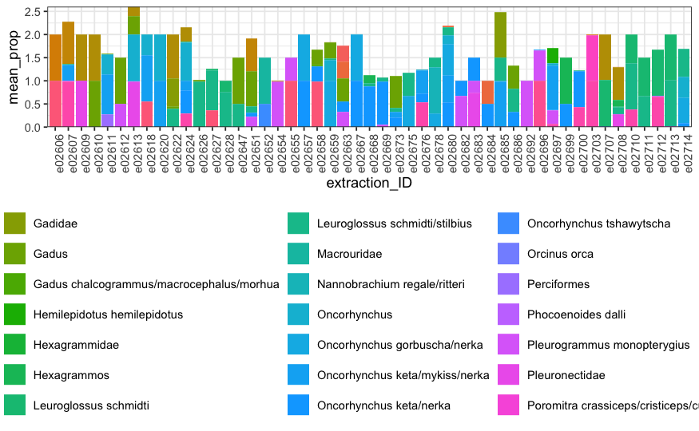

```r
slim_df %>%
  filter(sum(mean_prop) > 1) %>%
  ggplot(aes(x = extraction_ID, y = mean_prop, fill = taxa)) +
  geom_bar(stat = "identity", position = "stack") +
  theme_bw() +
  theme(
    legend.position = "bottom",
    axis.text.x = element_text(angle = 90)
  ) +
  scale_y_continuous(expand = c(0,0))
```

```r
NA
NA
```

[figure not shown]

```r
combined_meta_w_edna <- meta %>%
  left_join(., slim_df) %>%
  rename(proportion_sequencing_reads = new_prop) %>%
  select(-taxa_prop, -new_tot_prop)
```

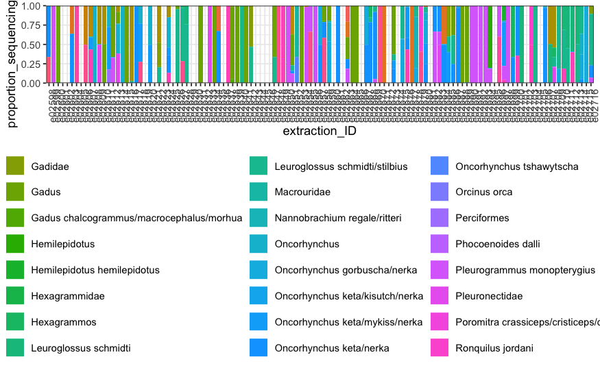

```r
combined_meta_w_edna %>%
  ggplot(aes(x = extraction_ID, y = proportion_sequencing_reads, fill = taxa)) +
  geom_bar(stat = "identity", position = "stack") +
  theme_bw() +
  theme(
    legend.position = "bottom",
    axis.text.x = element_text(angle = 90)
  ) +
  scale_y_continuous(expand = c(0,0))

ggsave("pdf_outputs/eDNA_by_filter.png", height = 10, width = 15)
```

the other way to provide these data to MML is by station, i.e., summing across the three filters at a given station.

```r
combined_meta_w_edna %>%
  write_csv("csv_outputs/Bogoslof_eDNA_w_metadata_20260121.csv")

# single list per sampling location:
combined_meta_w_edna %>%
  select(-proportion_sequencing_reads) %>%
  group_by(Transect, StationKM) %>%
  mutate()
```

| extraction_ID | lat | lon | Year | Month | Day | Transect | StationKM | DepthM | SampleNumber | SampleType | Sampler1 | Sampler2 | Notes | source | collection_year | collection_month | collection_day | location1 | location2 | location3 | longitude | latitude | sample_type | depth | time_of_day | project | collected_by | extraction_by | extraction_date | … |
| --- | --- | --- | --- | --- | --- | --- | --- | --- | --- | --- | --- | --- | --- | --- | --- | --- | --- | --- | --- | --- | --- | --- | --- | --- | --- | --- | --- | --- | --- | --- |
| e02598 | 53.39740 | -169.2485 | 2023 | 8 | 7 | west | 100 | 15 | 1 | eDNA | D. Baetscher | T. Zeppelin | Niskin top didn't close | water | 2023 | 8 | 7 | Bogoslof | west | 100 | NA | NA | sample | 15 | NA | Bogo fur seal eDNA | D. Baetscher | JLM | 10/10/2023 | … |
| e02598 | 53.39740 | -169.2485 | 2023 | 8 | 7 | west | 100 | 15 | 1 | eDNA | D. Baetscher | T. Zeppelin | Niskin top didn't close | water | 2023 | 8 | 7 | Bogoslof | west | 100 | NA | NA | sample | 15 | NA | Bogo fur seal eDNA | D. Baetscher | JLM | 10/10/2023 | … |
| e02598 | 53.39740 | -169.2485 | 2023 | 8 | 7 | west | 100 | 15 | 1 | eDNA | D. Baetscher | T. Zeppelin | Niskin top didn't close | water | 2023 | 8 | 7 | Bogoslof | west | 100 | NA | NA | sample | 15 | NA | Bogo fur seal eDNA | D. Baetscher | JLM | 10/10/2023 | … |
| e02599 | 53.39740 | -169.2485 | 2023 | 8 | 7 | west | 100 | 15 | 2 | eDNA | D. Baetscher | T. Zeppelin | Niskin top didn't close | water | 2023 | 8 | 7 | Bogoslof | west | 100 | NA | NA | sample | 15 | NA | Bogo fur seal eDNA | D. Baetscher | JLM | 10/10/2023 | … |
| e02599 | 53.39740 | -169.2485 | 2023 | 8 | 7 | west | 100 | 15 | 2 | eDNA | D. Baetscher | T. Zeppelin | Niskin top didn't close | water | 2023 | 8 | 7 | Bogoslof | west | 100 | NA | NA | sample | 15 | NA | Bogo fur seal eDNA | D. Baetscher | JLM | 10/10/2023 | … |
| e02599 | 53.39740 | -169.2485 | 2023 | 8 | 7 | west | 100 | 15 | 2 | eDNA | D. Baetscher | T. Zeppelin | Niskin top didn't close | water | 2023 | 8 | 7 | Bogoslof | west | 100 | NA | NA | sample | 15 | NA | Bogo fur seal eDNA | D. Baetscher | JLM | 10/10/2023 | … |
| e02600 | 53.39740 | -169.2485 | 2023 | 8 | 7 | west | 100 | 15 | 3 | eDNA | D. Baetscher | T. Zeppelin | Niskin top didn't close | water | 2023 | 8 | 7 | Bogoslof | west | 100 | NA | NA | sample | 15 | NA | Bogo fur seal eDNA | D. Baetscher | JLM | 10/10/2023 | … |
| e02600 | 53.39740 | -169.2485 | 2023 | 8 | 7 | west | 100 | 15 | 3 | eDNA | D. Baetscher | T. Zeppelin | Niskin top didn't close | water | 2023 | 8 | 7 | Bogoslof | west | 100 | NA | NA | sample | 15 | NA | Bogo fur seal eDNA | D. Baetscher | JLM | 10/10/2023 | … |
| e02600 | 53.39740 | -169.2485 | 2023 | 8 | 7 | west | 100 | 15 | 3 | eDNA | D. Baetscher | T. Zeppelin | Niskin top didn't close | water | 2023 | 8 | 7 | Bogoslof | west | 100 | NA | NA | sample | 15 | NA | Bogo fur seal eDNA | D. Baetscher | JLM | 10/10/2023 | … |
| e02601 | NA | NA | 2023 | 8 | 7 | west | NA | 15 | 4 | FieldBlank | D. Baetscher | T. Zeppelin | NA | water | 2023 | 8 | 7 | Bogoslof | west | NA | NA | NA | field_blank | 15 | NA | Bogo fur seal eDNA | D. Baetscher | JLM | 10/10/2023 | … |

[output cut: 374 more lines]

```r
NA
```